# Mark_Flights

Author

Mark Kuria

This Homework Project works with dataframes in the package `nycflights13` about flights, specifically a sample of domestic flights that departed from the three major New York City airports in 2013.

# 1 Data overview

## 1.1 Package loading

## 1.2 Package overview

- The data package `nycflights13` package contains five tabular data frames. In total there is information about:
  - 16 **airlines**
  - 1458 **airports**
  - 3322 **planes**
  - 336776 **flights**

The core dataframe `flights` has the following variables:

`year`, `month`, `day`: **Date** of departure.  
`dep_time`, `arr_time`: Actual **departure** and **arrival** times (format HHMM or HMM), local time zone.  
`sched_dep_time`, `sched_arr_time`: **Scheduled departure** and **arrival** times (format HHMM or HMM), local time zone.  
`dep_delay`, `arr_delay`: **Departure** and **arrival delays**, in minutes. Negative times represent early departures/arrivals.  
`carrier`: Two letter **carrier** abbreviation. See `airlines`-dataframe to get the full name.

`flight`: airline’s flight number.  
`tailnum`: plane’s tail number (unique aircraft ID).  
`origin`, `dest`: three-letter airport codes for departure and arrival; full names/locations are in `airports`.  
`air_time`: minutes spent in the air.  
`distance`: distance flown in miles.  
`hour`, `minute`: scheduled departure hour and minute.  
`time_hour`: scheduled departure time rounded to the hour (date-time), useful for joining with `weather`.

# 2 Basic data visualization

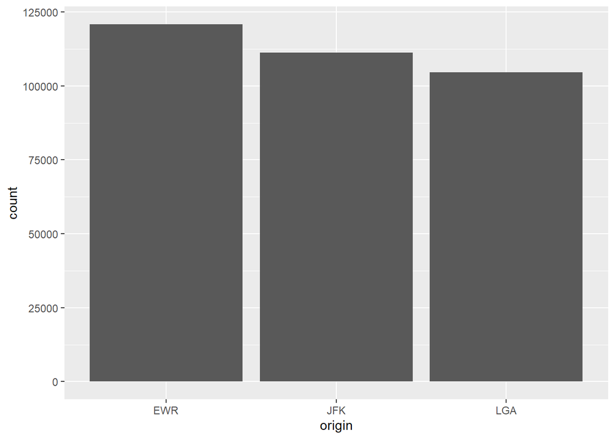

```r
ggplot(data = flights, mapping = aes(x = origin)) +
  geom_bar()
```

In the `flights` dataframe, the `EWR` variable has **120835** rows, the `JFK` has **111279** rows, and the LGA airport has **104662** rows, resulting in a total of **336776** flights

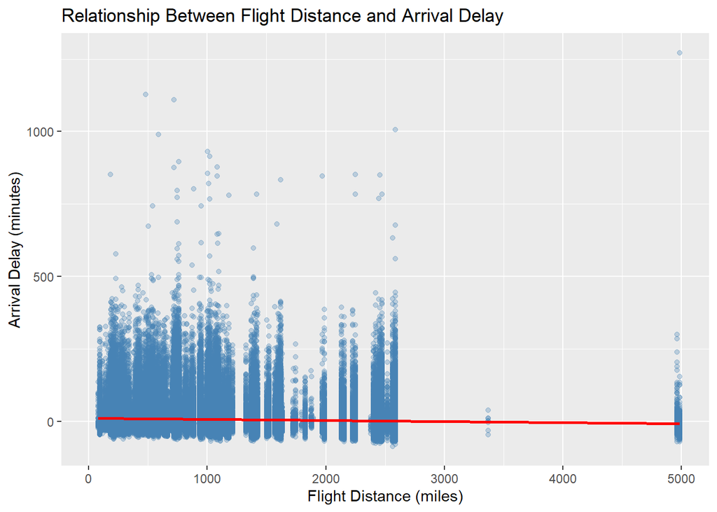

```r
flights %>%
  ggplot(aes(x = distance, y = arr_delay)) +
  geom_point(alpha = 0.3, color = "steelblue") +
  geom_smooth(method = "lm", color = "red") +
  labs(
    title = "Relationship Between Flight Distance and Arrival Delay",
    x = "Flight Distance (miles)",
    y = "Arrival Delay (minutes)"
  )
```